# Introduction to Statistical Learning Ch1, 2

Andrew Washburn

4/28/2018

# 1. Introduction

*Statistical learning* is a vast set of tools for *understanding data*. *Supervised learning*: build a statistical model relating *inputs* to *output* $y = ax + b$ (*linear model*) *Unsupervised learning*: understand structure of data with no outputs

### *Wage Data*

Wages for a group of males in the U.S Atlantic region. Examine association between `age` and `education` as well as `year`, on his `wage`.

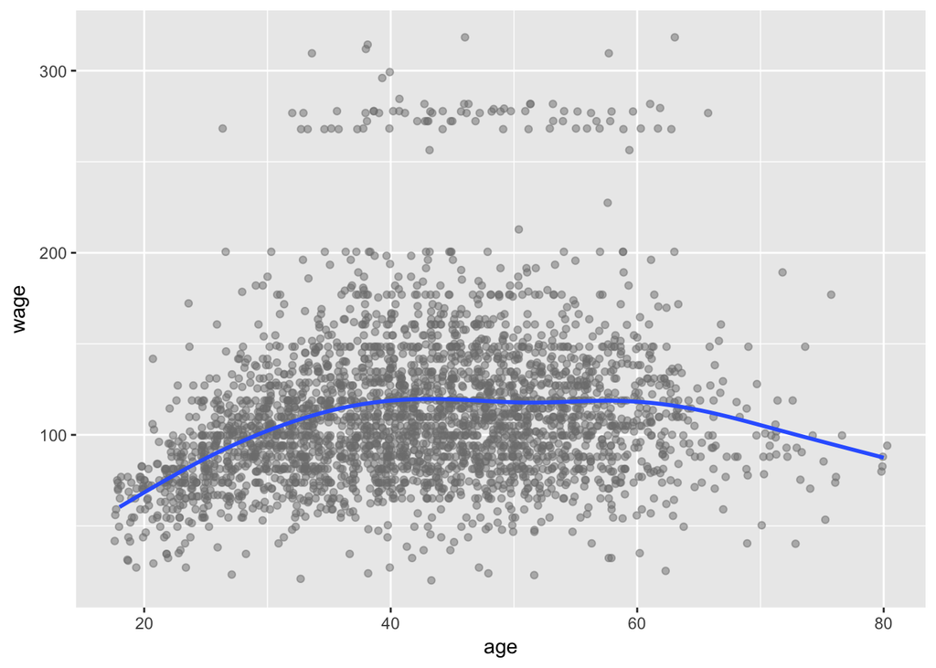

```r
#Wage data
ggplot(Wage, aes(age, wage)) +
  geom_jitter(color = "grey50", alpha = 1/2) +
  geom_smooth(se = F)
```

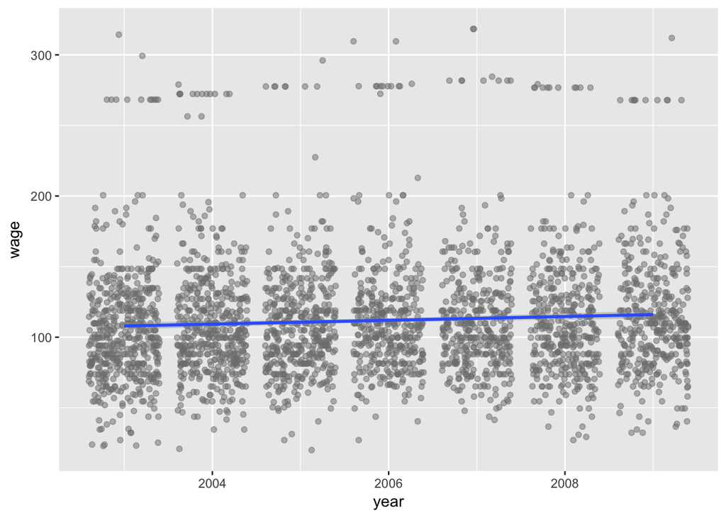

```r
ggplot(Wage, aes(year, wage)) +
  geom_jitter(color = "grey50", alpha = 1/2) +
  geom_smooth(method = "lm")
```

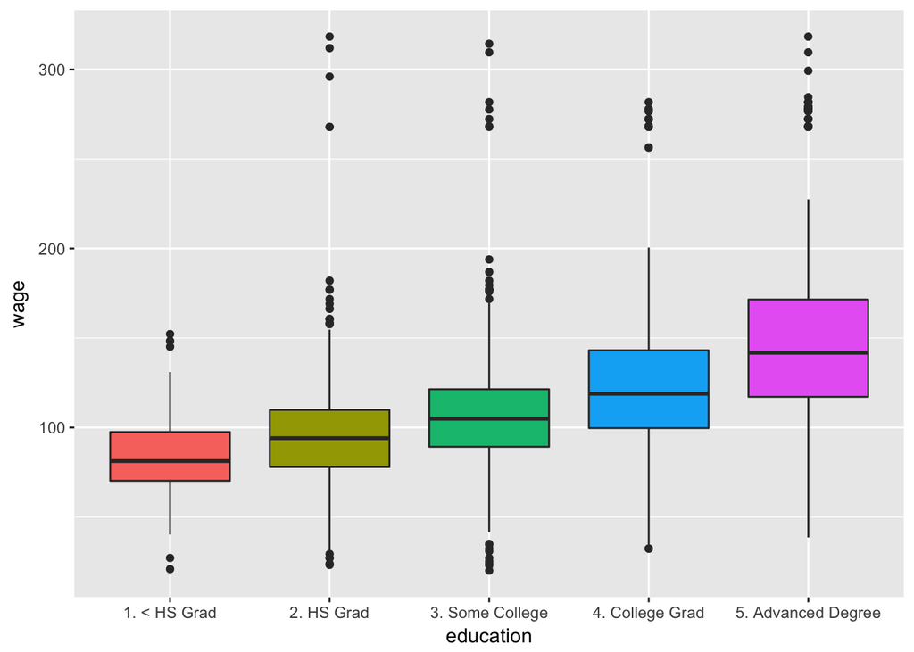

```r
ggplot(Wage, aes(education, wage)) +
  geom_boxplot(aes(fill = education), show.legend = F)
```

### Stock Market Data

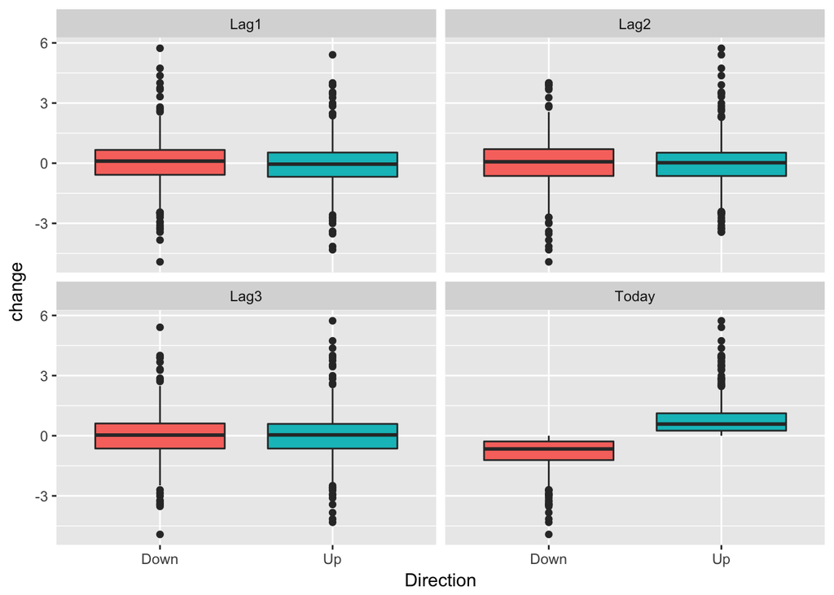

```r
# Smarket data
ggplot(Smarket %>% gather(day, change, c(Today, Lag1, Lag2, Lag3)), aes(Direction, change)) +
  geom_boxplot(aes(fill = Direction), show.legend = F) +
  facet_wrap(~ day)
```

No obvious relationship between previous stock market movements and today’s stock movement.

### Gene Expression Data

No output variables, so this is *unsupervised*, or a *clustering* problem. The `NCI60` dataset contains 6,830 gene expression observations and 64 cancer cell lines. Extracting the *principle components* summarizes the 6,830 observations into two dimnesions $Z_1$ and $Z_2$.

### The purpose of this book

1. Many statistical learning methods are relevant and useful in a wide range of academic and non-academic disciplines, beyond just the statistical sciences.
2. Statistical learning should not be viewed as a series of black boxes.
3. While it is important to know what job is performed by each cog, it is not necessary to have the skills to construct the machin inside the box! *Essentials for Statistical Learning* teaches how to build the machine in the box. *Introduction to Statistical Learning* teaches the rules of thumb on how to use the models. It’s possible to read this entire book without knowledge of matrix algebra and vectors.
4. We presume that the reader is interested in applying statistical learning methods to real-world problems.

### Notation and Simple Matrix Algebra

$n$ is the number of distinct observations, or data point. $p$ is the number of variables available for prediction. Example: `Wage` contains $n = 3,000$ observations and $p = 12$ variables (`year, age, sex`, and more).

$x_{ij}$ is the $j$th variables for the $i$th observation where $i = 1, 2, ..., n$ and $j = 1, 2, ..., p$. $\mathbf{X}$ denotes a $n \times p$. $x_i$ denotes the $i$th vector row of observations. $x_j$ denotes the $p$ vector variable row. Indicating the dimension of a particular object. $a \in \Bbb R$ means $a$ is a rela number. $a \in \Bbb R^n$ means $a$ is a vector length $n$. $\mathbf{A} \in \Bbb R^{r \times d} \text{ and } \mathbf{B} \in \Bbb R^{d \times a}$ is useful for multiplying matrices: $AB \in \Bbb R^{r \times a}$.

# 2. Statistical Learning

Input variables $X = (X_1, X_2, ..., X_p)$ (sometimes called predictors, independent variables, or features) are associated to an output variable $Y$ (often called the response or dependent variable). The difference in the relationship is called the error $\epsilon$. Very generally, this relationship can be described as:
$$Y = f(X) + \epsilon$$

### Why estimate $f$

#### Prediction

$$\hat{Y} = \hat{f}(X)$$
$\hat{f}$ is treated as a black box, as long as $\hat{Y}$ provides good predictions for $Y$. *Reducible Error*: the accuracy of $\hat{f}$ in estimating $f$. We can work on this. *Irreducible Error*: the error $\epsilon$ that is also a function of $Y$. Cannot reduce this. Error is the sum of all variables that are not measured. Therefore, we cannot modify $f$ to predict on them. Given an estimate function and set of predictors, we can estimate $\hat{Y}$ and describe the expected value as such:
$$E(Y - \hat{Y})^2 = \underbrace{[f(X) - \hat{f}(X)]^2}_\text{Reducible} + \underbrace{\text{Var}(\epsilon)}_\text{Irreducible}$$
Where $E(Y - \hat{Y})^2$ is the average expected value.

#### Inference

Sometimes we want to know how changes in $X$ affect changes in $Y$. Now we need to know the form of $f$ in the relationship $Y = f(X) + \epsilon$. Some questions could be: -Which predictors are associated with the response? -What is the relationship between the response and each predictor? -Can the relationship between $Y$ and each predictor be adequately summarized using a linear equation, or is the relationship more complicated?

### How to estimate $f$?

*Training Data*: observations used to create a model. Our goal: apply a statistical learning method to find a function $\hat{f}$ such that $Y \approx \hat{f}(X)$ for any observation $(X,Y)$.

#### Parametric Methods

Parametric simply means reducing the problem of finding $f$ to estimating a set of coefficients. The procedure follows in two-steps:

1. Assue a functional form. Example: linear form :
   $$f(X) = \beta_0 + \beta_1 X_1 + \beta_2 X_2 + \cdots + \beta_p X_p$$
   Only need to estimate $p+1$ coefficients $\beta_0, \beta_1, \beta_2, \cdots, \beta_p$.
2. Use a procedure to apply training data to *fit* the model such that
   $$Y \approx \beta_0 + \beta_1 X_1 + \beta_2 X_2 + \cdots + \beta_p X_p$$
   Most common approach fitting linear models is *(ordinary) least squares*.

#### Non-parametric Methods

Does not make assumptions about the functional form of $f$. More accurately follows the data, but requires a lot more data to become accurate.

#### Trade-Off between Prediction Accuracy and Model Interpretability

More flexible :: More accuracy. Easy interpretability :: Easy to infer.

#### Regression vs. Classification Problems

Quantitative :: Regression. Qualitative :: Classification.

### Assessing Model Accuracy

No free lunch in statistics: no one method dominates all others for all possible data sets. #### Measuring Quality of Fit Most common regression measure of fit is the *mean squared error* (MSE) given by
$$MSE = \frac{1}{n}\sum_{i=1}^{n}(y_i - \hat{f}(x_i))^2$$
Basically adding all the squared errors (so they add) then normalizing by the size of observations. We are interested in the MSE on observations outside the *training* dataset, the *test* dataset. The more flexible a model, or the more *degrees of freedom* it has, the better it can fit the training set. Linear regression has only two degrees of freedom, the most restrictive. But a more flexible model can overfit the training set and perform poorly with a test set.

#### Bias-Variance Trade-Off

It is possible to show that the expected test MSE, for a given value $x_0$, can always be decomposed into the sum of three fundamental quantities: 1. The variance of $\hat{f}(x_0)$ 2. The squared bias of $\hat{f}(x_0)$ 3. The variance of the error $\epsilon$
$$E(y_0 - \hat{f}(x_0))^2 = \text{Var}(\hat{f}(x_0)) + [\text{Bias}(\hat{f}(x_0))]^2 + \text{Var}(\epsilon)$$
This means we need a model that simultaneously minimizes the *variance* and *bias* of $\hat{f}(x_0)$.
*Variance*: the amount $\hat{f}$ changes if a different training set is used. In general more flexible models have higher variance. *Bias*: error from approximating a complicated model with a more restrictive one. More flexible models have less bias.

#### The Classification Setting

Use the training error rate
$$\frac{1}{n} \sum_{i = 1}^n I(y_i \neq \hat{y}_i)$$
Where $I(y_i \neq \hat{y}_i)$ is 0 when correct and 1 incorrect for each observation. *Bayes Classifier*: test erro rate is minimized, on average, by assigning each observation to the most likely class given its predictor values.
$$\text{Pr}(Y = j | X = x_0)$$
In a binary classifier, the following corresponds to *Class 1* $\text{Pr}(Y = 1 | X = x_0) > 0.5$, and *Class 2* otherwise. *K-Nearest Neighbors*: identifies the $K$ points nearest to $x_0$. The higher $K$, the higher bias, the lower $K$ the higher variance.

### R Lab

```r
x <- c(1,6,2); y <- c(1,4,3)
ls() # lists all variables in the environment
```

```
## [1] "x" "y"
```

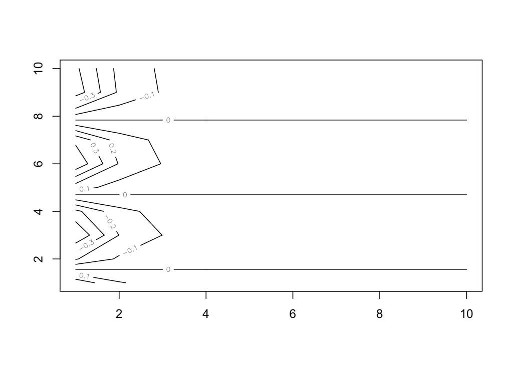

```r
rm(x, y) # remove variable

x <- 1:10; y <- x
f <- outer(x, y, function(x,y) cos(y) / (1 + x^2))
contour(x,y,f)
```

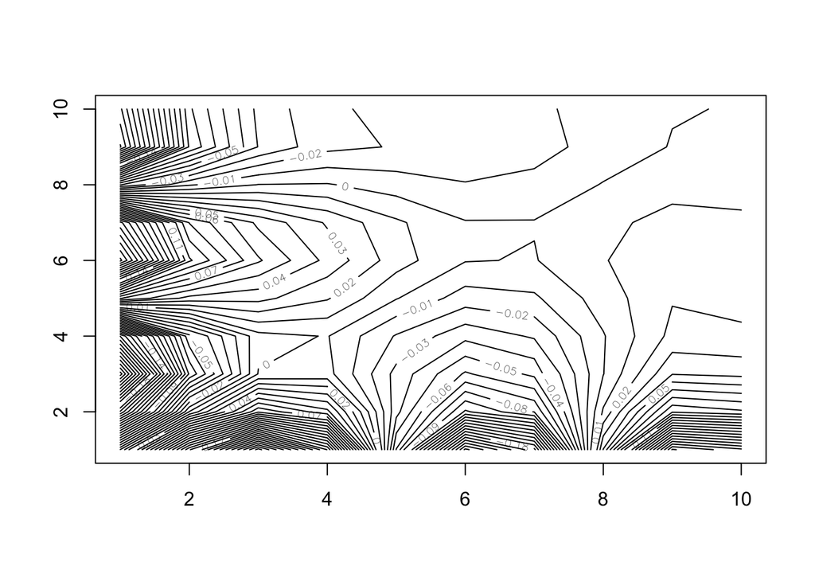

```r
fa <- (f - t(f)) / 2
contour(x,y,fa, nlevels = 45)
```

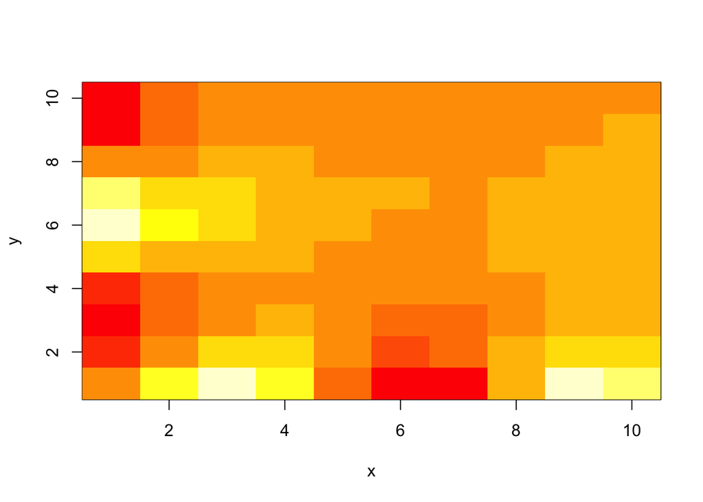

```r
image(x,y,fa)
```

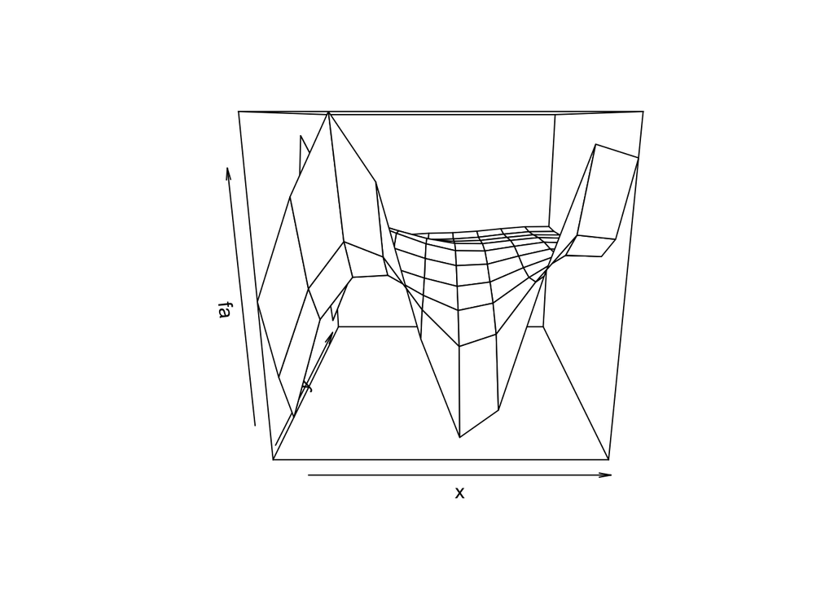

```r
persp(x,y,fa)
```

```r
summary(Auto)
```

```
##       mpg          cylinders      displacement     horsepower
##  Min.   : 9.00   Min.   :3.000   Min.   : 68.0   Min.   : 46.0
##  1st Qu.:17.00   1st Qu.:4.000   1st Qu.:105.0   1st Qu.: 75.0
##  Median :22.75   Median :4.000   Median :151.0   Median : 93.5
##  Mean   :23.45   Mean   :5.472   Mean   :194.4   Mean   :104.5
##  3rd Qu.:29.00   3rd Qu.:8.000   3rd Qu.:275.8   3rd Qu.:126.0
##  Max.   :46.60   Max.   :8.000   Max.   :455.0   Max.   :230.0
##
##      weight      acceleration        year           origin
##  Min.   :1613   Min.   : 8.00   Min.   :70.00   Min.   :1.000
##  1st Qu.:2225   1st Qu.:13.78   1st Qu.:73.00   1st Qu.:1.000
##  Median :2804   Median :15.50   Median :76.00   Median :1.000
##  Mean   :2978   Mean   :15.54   Mean   :75.98   Mean   :1.577
##  3rd Qu.:3615   3rd Qu.:17.02   3rd Qu.:79.00   3rd Qu.:2.000
##  Max.   :5140   Max.   :24.80   Max.   :82.00   Max.   :3.000
##
##                  name
##  amc matador       :  5
##  ford pinto        :  5
##  toyota corolla    :  5
##  amc gremlin       :  4
##  amc hornet        :  4
##  chevrolet chevette:  4
##  (Other)           :365
```

```r
?College
summary(College)
```

```
##  Private        Apps           Accept          Enroll       Top10perc
##  No :212   Min.   :   81   Min.   :   72   Min.   :  35   Min.   : 1.00
##  Yes:565   1st Qu.:  776   1st Qu.:  604   1st Qu.: 242   1st Qu.:15.00
##            Median : 1558   Median : 1110   Median : 434   Median :23.00
##            Mean   : 3002   Mean   : 2019   Mean   : 780   Mean   :27.56
##            3rd Qu.: 3624   3rd Qu.: 2424   3rd Qu.: 902   3rd Qu.:35.00
##            Max.   :48094   Max.   :26330   Max.   :6392   Max.   :96.00
##    Top25perc      F.Undergrad     P.Undergrad         Outstate
##  Min.   :  9.0   Min.   :  139   Min.   :    1.0   Min.   : 2340
##  1st Qu.: 41.0   1st Qu.:  992   1st Qu.:   95.0   1st Qu.: 7320
##  Median : 54.0   Median : 1707   Median :  353.0   Median : 9990
##  Mean   : 55.8   Mean   : 3700   Mean   :  855.3   Mean   :10441
##  3rd Qu.: 69.0   3rd Qu.: 4005   3rd Qu.:  967.0   3rd Qu.:12925
##  Max.   :100.0   Max.   :31643   Max.   :21836.0   Max.   :21700
##    Room.Board       Books           Personal         PhD
##  Min.   :1780   Min.   :  96.0   Min.   : 250   Min.   :  8.00
##  1st Qu.:3597   1st Qu.: 470.0   1st Qu.: 850   1st Qu.: 62.00
##  Median :4200   Median : 500.0   Median :1200   Median : 75.00
##  Mean   :4358   Mean   : 549.4   Mean   :1341   Mean   : 72.66
##  3rd Qu.:5050   3rd Qu.: 600.0   3rd Qu.:1700   3rd Qu.: 85.00
##  Max.   :8124   Max.   :2340.0   Max.   :6800   Max.   :103.00
##     Terminal       S.F.Ratio      perc.alumni        Expend
##  Min.   : 24.0   Min.   : 2.50   Min.   : 0.00   Min.   : 3186
##  1st Qu.: 71.0   1st Qu.:11.50   1st Qu.:13.00   1st Qu.: 6751
##  Median : 82.0   Median :13.60   Median :21.00   Median : 8377
##  Mean   : 79.7   Mean   :14.09   Mean   :22.74   Mean   : 9660
##  3rd Qu.: 92.0   3rd Qu.:16.50   3rd Qu.:31.00   3rd Qu.:10830
##  Max.   :100.0   Max.   :39.80   Max.   :64.00   Max.   :56233
##    Grad.Rate
##  Min.   : 10.00
##  1st Qu.: 53.00
##  Median : 65.00
##  Mean   : 65.46
##  3rd Qu.: 78.00
##  Max.   :118.00
```

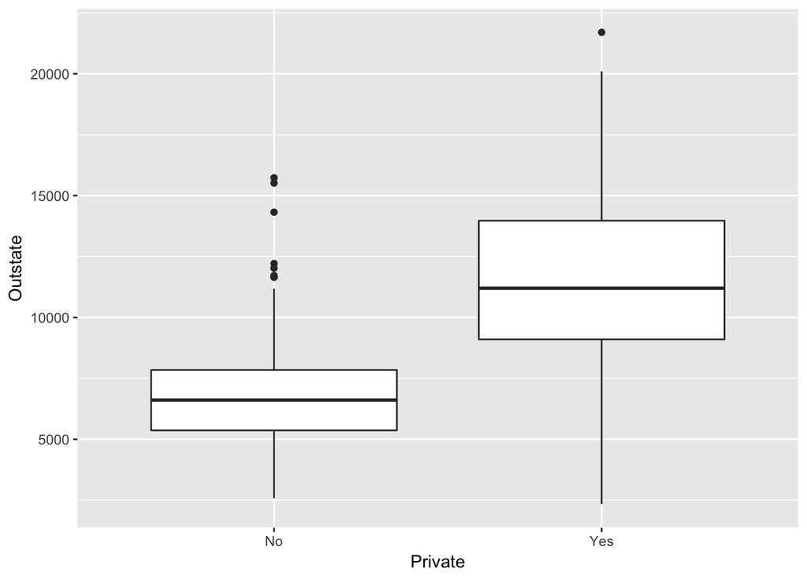

```r
College %>%
  ggplot(aes(Private, Outstate)) +
  geom_boxplot()
```

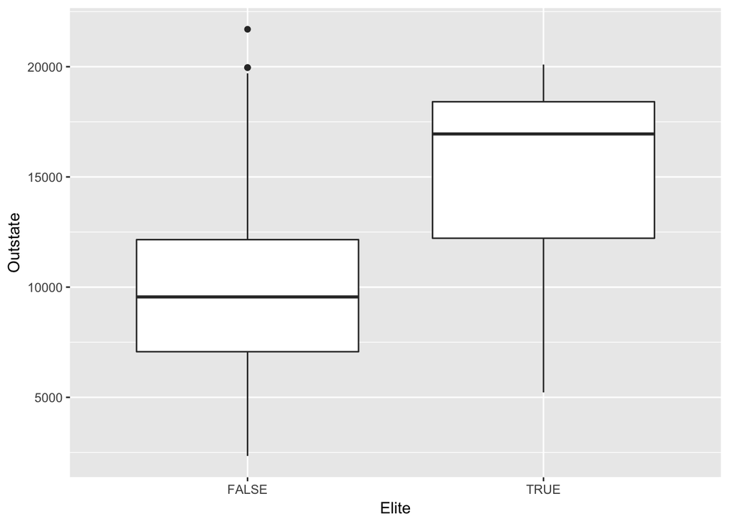

```r
College <- College %>%
  mutate(Elite = Top10perc > 50)
ggplot(College, aes(Elite, Outstate)) + geom_boxplot()
```